# Rプログラミング入門成績レポート

2026年07月30日

## 概要

- 単位取得者18名：平均 89.4 点、中央値 92.0 点。
- 90点以上：11 名（61.1%）。
- 履修者27名：単位取得者18名、途中放棄者9名。
- 3年生18名：単位取得者15名、平均 88.7 点。

## 集計方法

成績統計は単位取得者18名を対象とし、途中放棄者の得点は0点にせず、欠損値として扱いました。履修状況・分布の分母は27名です。

## 全体集計

全体の履修状況と成績統計

| 指標 | 値 |
| --- | --- |
| 履修者数 | 27人 |
| 単位取得者 | 18人 |
| 途中放棄者 | 9人 |
| 単位取得率 | 66.7% |
| 平均点 | 89.4点 |
| 中央値 | 92.0点 |
| 標準偏差 | 6.6点 |
| 最低点 | 78点 |
| 最高点 | 100点 |

平均点は 89.4 点、中央値は 92.0 点で、70～80点台の得点が平均をやや押し下げています。途中放棄者は全体の 33.3%を占めますが、最後まで取り組んだ学生の多くは良い成績を収めました。

## 成績分布

途中放棄者を独立した棒として表示しています。高得点や途中放棄者の割合が目立ちます。

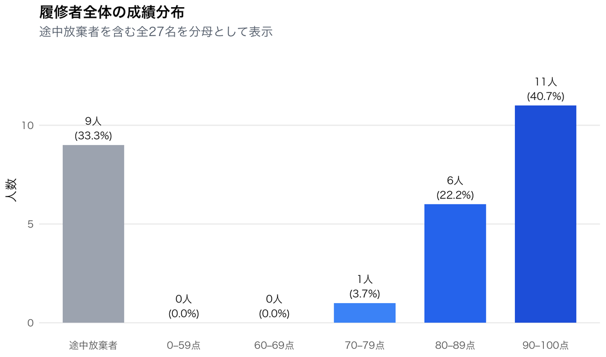

90～100点は11名で最も多く、次いで途中放棄者が9名、80～89点が6名です。単位取得者だけを見ると、90点以上が61.1%を占めます。

## 学年別集計

学年別の平均点は単位取得者のみで計算しています。特に1・2・4年生は単位取得者が各1名のため、平均点を学年間の優劣として解釈することはできません。

学年別の履修状況と成績統計

| 学年 | 履修者数 | 単位取得者 | 途中放棄者 | 単位取得率 | 平均点 | 中央値 | 標準偏差 | 得点範囲 |
| --- | --- | --- | --- | --- | --- | --- | --- | --- |
| 1 | 2 | 1 | 1 | 50.0% | 92.0 | 92.0 | — | 92–92 |
| 2 | 3 | 1 | 2 | 33.3% | 92.0 | 92.0 | — | 92–92 |
| 3 | 18 | 15 | 3 | 83.3% | 88.7 | 90.0 | 6.99 | 78–100 |
| 4 | 4 | 1 | 3 | 25.0% | 96.0 | 96.0 | — | 96–96 |

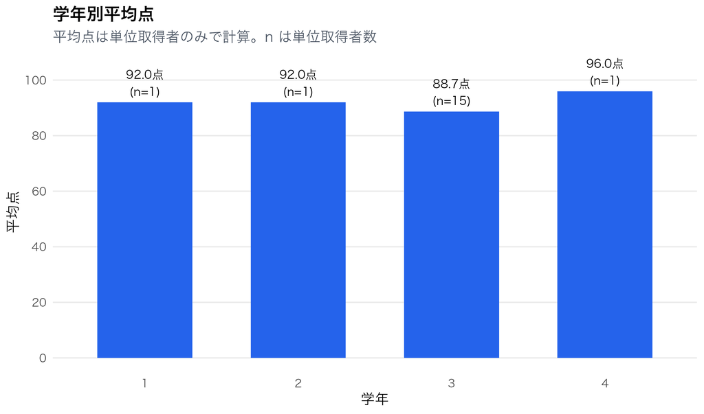

3年生は単位取得者が15名で、平均点88.7点、中央値90.0点、得点範囲78～100点です。他学年は単位取得者が1名ずつだけである。

## 学年別の単位取得状況

平均点とは別に、各学年の履修者のうち何名に数値の成績が記載されているかを示します。

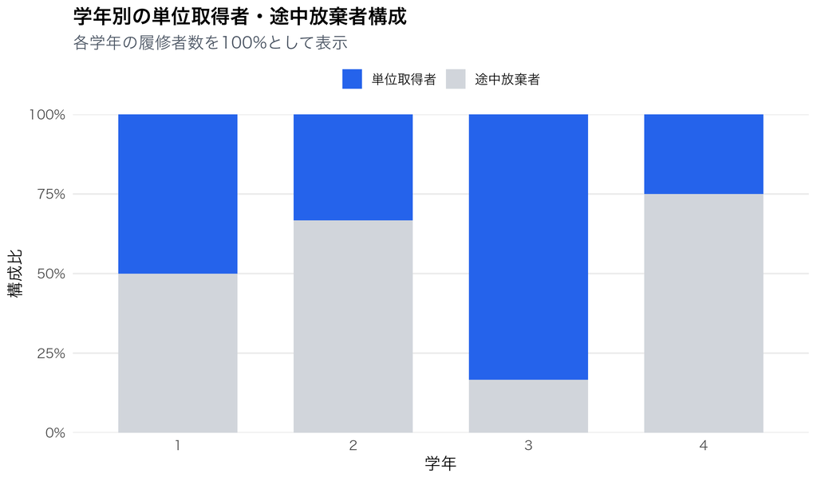

3年生の単位取得率は83.3%で最も高く、1年生50.0%、2年生33.3%、4年生25.0%です。ただし、1・2・4年生は履修者数自体が少ないため、割合は1名の違いで大きく変動します。

## 授業担当者からの講評

今回のR課題では、ほぼ全員がAIを使っていました。AIを禁止するつもりはありませんし、使うこと自体も悪くありません。実際、**プログラミング未経験の学生でも、AIを使えば経験者との差をかなり早く縮められます。**その分、もともとできる学生は「では、自分はどこで差をつけるのか」を考える必要があります。おそらく、大学の授業だけでなく、就活などでも生存戦略を考えなければなりません。

最終レポートでは、そこに大きな差が出ました。きれいな図を1枚貼って終わる人もいれば、図から何が分かるのかを自分の言葉で説明し、聞き手に伝えようとした人もいました。高く評価したのは後者です。**グラフを作ることは分析のスタートで、そこから何を読み取り、どう伝えるかが一番大切です。**